# Addendum to COVID-19 – exploring the implications of long-term condition type and extent of multimorbidity on years of life lost: a modelling study

Peter Hanlon, Fergus Chadwick, Anoop Shah, Rachael Wood, Jon Minton, Gerry McCartney, Colin Fischbacher, Frances S Mair, Dirk Husmeier, Jason Matthiopoulos and David A McAllister

# Executive summary

# Introduction

We received several interesting and useful suggestions, as well as some press reports, concerning publication of [version](https://wellcomeopenresearch.org/articles/5-75) one of our recent manuscript. In response to these, we have undertaken further analyses and produced additional tables and plots.

We will shortly incorporate these into another version of the manuscript which will be available via the Wellcome Open Research journal, but in view of the attention that the work received we have opted to post this additional work rapidly via placing it immediately on our [project github repository](https://github.com/dmcalli2/covid19_yll_final).

Specifically this addendum addresses:-

- The impact of whether using different life tables would change the results
- Why accounting for the number and type of long-term conditions does not have a large impact on the average years of life lost
- The limited generalisability of these findings for special populations such as care homes.

# The impact of using different life tables

In our original analysis we used the Global Burden of Disease 2010 (GBD-2010) life tables rather than UK or Italian life tables. We did so to allow comparison of the burden of COVID-19 against other causes of death within an international framework. This was true both for the simple “standard” comparison, and in the more complex analysis additionally accounting for the number and type of long-term conditions (as a post-modelling correction).

Some commentators interpreted our estimated YLL, however, as being the YLL for the UK. However, our intention was for our estimates to be comparable with other causes of death where the YLL was also benchmarked against the GBD 2010 life tables. Although the age-distribution for deaths from COVID-19 that we used originated from the Italian Istituto Superiore di Sanita (ISS) report, this was understandable given that we (i) used data from Wales to estimate the impact of number of long-term conditions in the general population, (ii) included some (albeit a small amount) of data from Scotland to inform our modelling and (iii) are UK-based researchers.

We have therefore added a series of sensitivity analyses using national lifetables for the UK and other countries, to examine whether greater consistency in the populations and time period across our data sources, and the closer alignment with the current UK context, makes a substantial difference to the overall YLL estimates.

### Figure A1 Life tables

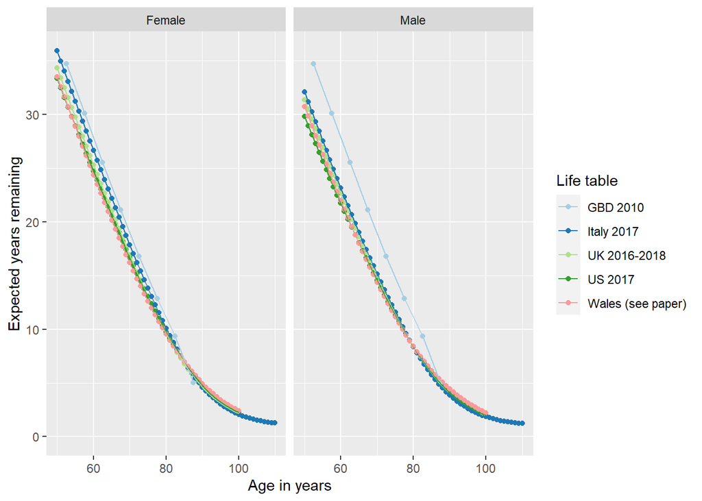

### Table A1 Years of life lost by sex and life table, unadjusted and adjusted for number and type of long-term conditions

| Sex | Life Table | LTC number and type unadjusted | LTC number and type adjusted | Difference with adjustment (months) |
| --- | --- | --- | --- | --- |
| Total | GBD 2010 | 13.3* | 10.9 | 29 |
| Total | Italy 2017 | 11.4 | 9.7 | 21 |
| Total | UK 1016-2018 | 11.2 | 9.5 | 21 |
| Total | US 2017 | 11 | 9.3 | 21 |
| Total | Wales (see paper) | 11 | 9.3 | 21 |
| Male | GBD 2010 | 14* | 11.6 | 29 |
| Male | Italy 2017 | 11.6 | 9.8 | 20 |
| Male | UK 1016-2018 | 11.5 | 9.8 | 20 |
| Male | US 2017 | 11.2 | 9.5 | 20 |
| Male | Wales (see paper) | 11.3 | 9.6 | 20 |
| Female | GBD 2010 | 11.8* | 9.4 | 29 |
| Female | Italy 2017 | 10.9 | 9.2 | 21 |
| Female | UK 1016-2018 | 10.5 | 8.8 | 21 |
| Female | US 2017 | 10.5 | 8.8 | 21 |
| Female | Wales (see paper) | 10.3 | 8.6 | 21 |

*LTC: long-term conditions. * The GBD-2010 life tables were only available in 5-year bands, hence we estimated the YLL in the age-bands as presented in the ISS report. For the remaining tables, since these were available for single-years, we used single years of age derived from our age models.*

We would continue to argue that national agencies should estimate the YLL using their local age, sex and comorbidity data, where available. We recommend that the choice of life tables should reflect the specific question – for example national life tables should be used for within-country comparisons and GBD or similar life tables for international comparisons. However these results indicate that the choice of life table does not materially change the overall finding, that, on average, people dying from COVID-19 are losing around 10 years of life.

# Why accounting for the number and type of long-term conditions does not have a large impact on the total years of life lost

Some commentators have been surprised that adjusting for the number and type of long-term conditions does not have a larger impact on the YLL. Here, we present some additional results to help explain this finding. First, as has previously been described (https://www.ncbi.nlm.nih.gov/pmc/articles/PMC2424085/), the effect of most of the long-term conditions on mortality are attenuated with age (Table A2). This may partly explain why the estimated YLL was not greatly affected by adjusting for the number and type of long-term conditions.

### Table A2 Hazard ratios at selected ages estimated separately for men and women having mutually adjusted for all other variables included in the model

| Sex | Condition | Age 50 | Age 60 | Age 70 | Age 80 | Age 90 |
| --- | --- | --- | --- | --- | --- | --- |
| Female | Atrial fibrillation | 1.18 | 1.24 | 1.31 | 1.38 | 1.46 |
| Female | Cancer | 2.80 | 2.15 | 1.66 | 1.27 | 0.98 |
| Female | Chronic obstructive pulmonary disease | 3.89 | 2.95 | 2.24 | 1.70 | 1.29 |
| Female | Dementia | 4.98 | 3.99 | 3.19 | 2.56 | 2.05 |
| Female | Diabetes | 1.52 | 1.41 | 1.31 | 1.22 | 1.13 |
| Female | Heart failure | 2.09 | 1.87 | 1.67 | 1.50 | 1.34 |
| Female | Hypertension | 0.89 | 0.95 | 1.00 | 1.07 | 1.13 |
| Female | Ischaemic heart disease | 1.55 | 1.42 | 1.31 | 1.20 | 1.10 |
| Female | Liver failure | 3.29 | 2.48 | 1.87 | 1.41 | 1.06 |
| Female | Renal failure | 1.27 | 1.24 | 1.20 | 1.17 | 1.14 |
| Female | Stroke | 1.58 | 1.51 | 1.44 | 1.37 | 1.30 |
| Male | Atrial fibrillation | 1.13 | 1.18 | 1.24 | 1.30 | 1.37 |
| Male | Cancer | 2.10 | 1.80 | 1.54 | 1.31 | 1.12 |
| Male | Chronic obstructive pulmonary disease | 3.03 | 2.47 | 2.01 | 1.64 | 1.34 |
| Male | Dementia | 3.49 | 3.17 | 2.89 | 2.63 | 2.39 |
| Male | Diabetes | 1.54 | 1.39 | 1.26 | 1.14 | 1.03 |
| Male | Heart failure | 2.09 | 1.88 | 1.68 | 1.51 | 1.35 |
| Male | Hypertension | 0.98 | 1.01 | 1.04 | 1.07 | 1.11 |
| Male | Ischaemic heart disease | 1.28 | 1.24 | 1.20 | 1.17 | 1.13 |
| Male | Liver failure | 5.65 | 3.55 | 2.23 | 1.40 | 0.88 |
| Male | Renal failure | 1.21 | 1.22 | 1.23 | 1.24 | 1.25 |
| Male | Stroke | 1.67 | 1.57 | 1.48 | 1.39 | 1.31 |

However, we do not think that this “attenuation effect” is the most important factor for two reasons. Firstly, *within* the set of simulated patients, the number of long-term conditions (multimorbidity count) strongly impacted the YLL, even among the older groups. This can be seen in Table 2 in [version one of our recent manuscript](https://wellcomeopenresearch.org/articles/5-75), and in the similar table below (Table A3) modified to use the UK life table rather than the GBD-2010 life table.

### Table A3 Mean years of life lost among people dying from COVID-19, accounting for type of long-term conditions, by age-band, and multimorbidity count - with UK life table reference

#### Men

| Comorbidity count | 50-59 | 60-69 | 70-79 | 80 plus |
| --- | --- | --- | --- | --- |
| 0 | 32.24 | 23.71 | 17.17 | 4.27 |
| 1 | 32.57 | 23.72 | 15.43 | 4.35 |
| 2 | 28.86 | 21.16 | 12.91 | 3.02 |
| 3 | 26.81 | 18.47 | 10.71 | 2.27 |
| 4 | 23.62 | 15.90 | 9.21 | 1.02 |
| 5 | 21.51 | 15.07 | 6.93 | -0.09 |
| 6 | 18.01 | 11.06 | 5.48 | -1.76 |
| 7 | 18.37 | 8.61 | 3.80 | -1.71 |
| 8 | 18.90 | 7.45 | 2.84 | -2.29 |
| 9 | - | 12.06 | -5.79 | 3.73 |
| 10 | - | - | -8.62 | - |

#### Women

| Comorbidity count | 50-59 | 60-69 | 70-79 | 80 plus |
| --- | --- | --- | --- | --- |
| 0 | 33.79 | 29.99 | 17.79 | 4.97 |
| 1 | 36.23 | 26.90 | 17.97 | 5.09 |
| 2 | 32.46 | 23.75 | 15.92 | 3.09 |
| 3 | 31.65 | 21.86 | 14.22 | 1.60 |
| 4 | 28.47 | 20.12 | 11.84 | 0.37 |
| 5 | 26.66 | 18.60 | 10.10 | 0.03 |
| 6 | 20.16 | 16.71 | 9.44 | -0.71 |
| 7 | 22.09 | 13.72 | 8.14 | -1.91 |
| 8 | 28.67 | 18.56 | 7.52 | -1.73 |
| 9 | - | 10.67 | 8.43 | -4.75 |
| 10 | - | - | -0.03 | - |

Instead, we suspect that the main reason for the comparatively modest impact of adjusting for multimorbidity count on the overall YLL is that multimorbidity is common in older people among the general population, not solely in people who die from COVID-19. Figure A2 shows the observed (empirical) age-sex specific distribution of multimorbidity count in the Welsh population alongside the modelled age-sex distribution (see manuscript, this was derived from the marginal distributions from the ISS report as well as from models of the association between multimorbidity count and age among a small set of people coded as having died from influenza in Wales) for the ISS deaths. For most age-groups, multimorbidity counts were lower in the population than in people dying from COVID-19, but among older people were nonetheless high for both.

### Figure A2 Distribution of multimorbidity by age and sex

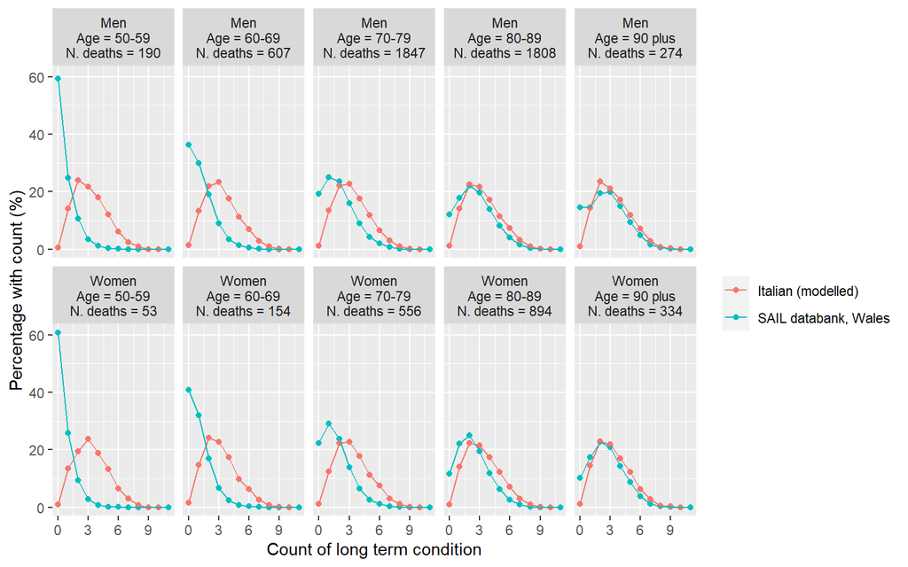

If we assume that age and long-term condition count are independent rather than associated, this does lead to a larger attenuation in YLL (see Table 1 of the main manuscript). However, even then the attenuation in YLL was less than two years, despite this being a somewhat extreme and implausible assumption.

In conclusion, a major driver of the fact that accounting for long-term condition count has only a modest effect on overall YLL is that, as well as being common in people who die from COVID-19, long-term conditions and multimorbidity are common in older people in the general population.

# The limitations of these findings for special populations such as care homes

Our work was completed before the recent concerns over COVID-19 deaths in care homes became prominent and was not designed to address this issue. It was designed instead to determine whether, since the presence of long-term conditions and multimorbidity are common among people who died from COVID-19, the years of life lost among people dying from COVID-19 can be assumed to be low. Our findings demonstrate that this is not the case.

Since inclusion in the Welsh dataset simply required having been being registered with a participating general practice (GP), and since all care home residents in the UK are registered with a local GP, people resident in care homes will have been included in our survival models. Moreover, although the comorbidity prevalence data from the ISS reports was based solely on hospitalised patients, the age-sex distribution from the ISS reports included anyone who died from COVID-19 provided they had tested positive for SARS CoV2. Therefore, care home residents will have contributed to the average YLL in the estimates we produced.

Nonetheless, we strongly agree that care home residents, are a special population, in whom more severe disease, multimorbidity and frailty are likely to be commoner. We also agree that there are good biological reasons for suspecting that care home residents may be over-represented among COVID-19 deaths compared to other causes of death (because it is an infectious disease and people in care homes are in a communal residence), and that the inclusion of more care home residents would likely have lowered the YLL in our analyses. Therefore, we would argue that the best approach for determining life expectancy in this group would be to estimate it using data which includes care home residency status.